# Naive Bayes

Marcin Mazurek

2017-10-26

# Twierdzenie Bayesa

$P(Y|X) = \frac{P(Y) * P(X|Y)}{P(X)}$

W przypadku, gdy $Y$ oznacza przynależność obserwacji do jednej z $K$ klas:

$P(Y_{k}|X) = \frac{P(Y_{k}) * P(X|Y_k)}{\sum_{k=1}^K{P(Y_k)*P(X|Y_{k})}}$

$P(Y_{k})$ prawdopodobieństwa apriori, wyznaczane na podstawie częstości występowania klas w próbie

$P(X|Y_k))$ prawdopodobieństwo zaobserwowania X przy założeniu przynależności do klasy $k$ -tej.

Reguła Bayesa:  
Zaobserwowany wektor x klasyfikujemy jako pochodzący z tej klasy k, dla której wartość  
$p_k(X) = P(Y_{k}|X)$ jest największa

# Naiwny klasyfikator Bayesa

## Predyktory dyskretne Multinomial naive Bayes

### Jeden predyktor

Jakie jest p-stwo przeżycia pasażera, jeżeli wiemy że ma bilet w określonej klasie (Pclass)?  
X - Pclass Y - Survived

Dla pasażerów pierwszej klasy p-stwo przeżycia wynosi:

$P(Survived=1|Pclass=1)=\frac{P(Survived=1) * P(Class=1|Survived=1)}{P(Pclass=1)}$

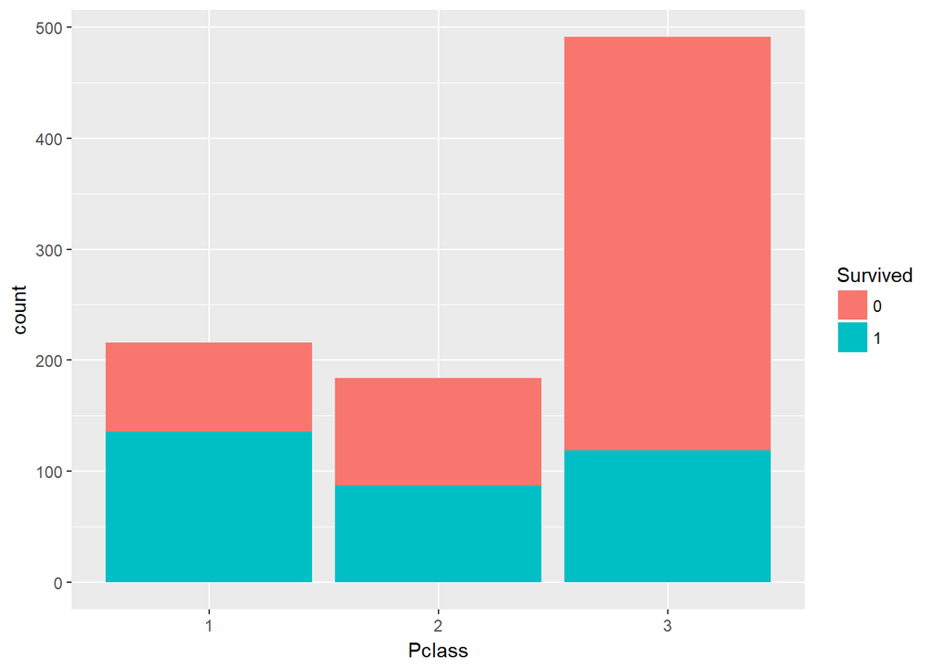

```r
library(titanic)
library(ggplot2)


train<-titanic_train
train$Survived<-as.factor(train$Survived)
train$Pclass<-as.factor(train$Pclass)
train$Sex<-as.factor(train$Sex)

ggplot(data=train, aes(Pclass, fill=Survived)) + geom_bar(stat="count", position="stack")
```

```r
table(train[c("Survived", "Pclass")])
```

```
##         Pclass
## Survived   1   2   3
##        0  80  97 372
##        1 136  87 119
```

```r
#p-stwo przeżycia (apriori)
P_Survived_1<-nrow(train[train$Survived==1,]) / nrow(train)
P_Survived_1
```

```
## [1] 0.3838384
```

```r
P_Survived_0<-nrow(train[train$Survived==0,]) / nrow(train)
P_Survived_0
```

```
## [1] 0.6161616
```

```r
#p-stwo bycia pasażerem pierwszej klasy
P_Class_1 <- nrow(train[train$Pclass==1,]) / nrow(train)

#p-stwo trafienia na pasażera pierszej klasy w grupie ocalonych
P_Class_1_Survived_1 <- nrow(train[train$Pclass==1 & train$Survived ==1,]) / nrow(train[train$Survived==1,])
P_Class_1_Survived_0 <- nrow(train[train$Pclass==1 & train$Survived ==0,]) / nrow(train[train$Survived==1,])

P_Survived_1_Pclass_1 <- (P_Survived_1 * P_Class_1_Survived_1) / (P_Class_1_Survived_1*P_Survived_1 + P_Class_1_Survived_0*P_Survived_0)
P_Survived_1_Pclass_1
```

```
## [1] 0.5143312
```

```r
P_Pclass<-table(train$Pclass)/sum(table(train$Pclass))

P_Class_Survived_1<-(table(train$Pclass, train$Survived)[,2])/ sum(table(train$Pclass, train$Survived)[,2])

#we wszystkich klasach:
P_Survived_1_Pclass <- P_Survived_1 * P_Class_Survived_1 / P_Pclass

P_Survived_1_Pclass
```

```
##
##         1         2         3
## 0.6296296 0.4728261 0.2423625
```

Wektor prawdopodobieństw przeżycia dla klasy wynosi więc: 0.6296296, 0.4728261, 0.2423625  
Dla porówania :

```r
P_Class_Survived_1<-(table(train$Pclass, train$Survived)[,2])/ (table(train$Pclass, train$Survived)[,1] + table(train$Pclass, train$Survived)[,2])

P_Survived_1_Pclass
```

```
##
##         1         2         3
## 0.6296296 0.4728261 0.2423625
```

```r
library(e1071)
model<-naiveBayes(Survived~Pclass, data=train)

pred<-suppressWarnings(predict(model, train, type="raw"))
model$apriori
```

```
## Y
##   0   1
## 549 342
```

```r
model$tables
```

```
## $Pclass
##    Pclass
## Y           1         2         3
##   0 0.1457195 0.1766849 0.6775956
##   1 0.3976608 0.2543860 0.3479532
```

```r
head(cbind(train$Pclass, pred),10)
```

```
##                 0         1
##  [1,] 3 0.7576375 0.2423625
##  [2,] 1 0.3703704 0.6296296
##  [3,] 3 0.7576375 0.2423625
##  [4,] 1 0.3703704 0.6296296
##  [5,] 3 0.7576375 0.2423625
##  [6,] 3 0.7576375 0.2423625
##  [7,] 1 0.3703704 0.6296296
##  [8,] 3 0.7576375 0.2423625
##  [9,] 3 0.7576375 0.2423625
## [10,] 2 0.5271739 0.4728261
```

### Więcej niż jedna zmienna objaśniająca

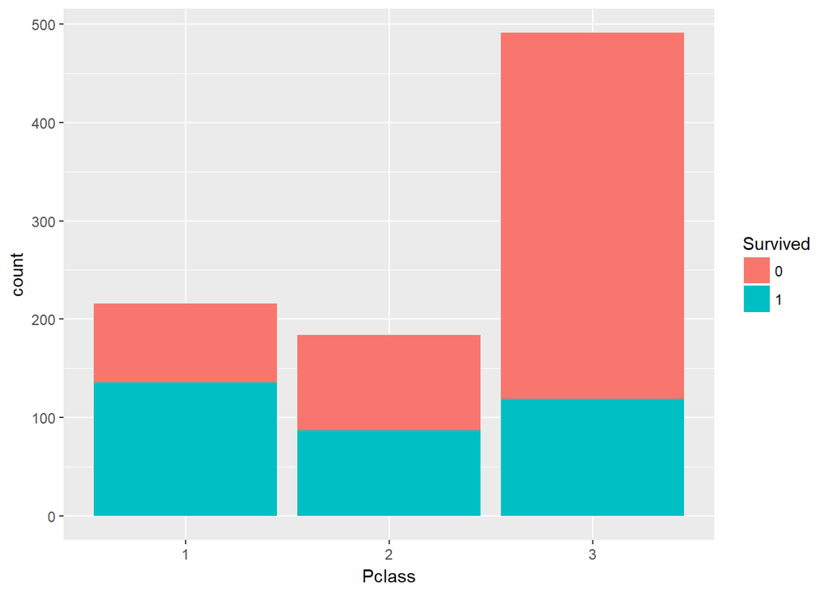

```r
ggplot(data=train, aes(Pclass, fill=Survived)) + geom_bar(stat="count", position="stack")
```

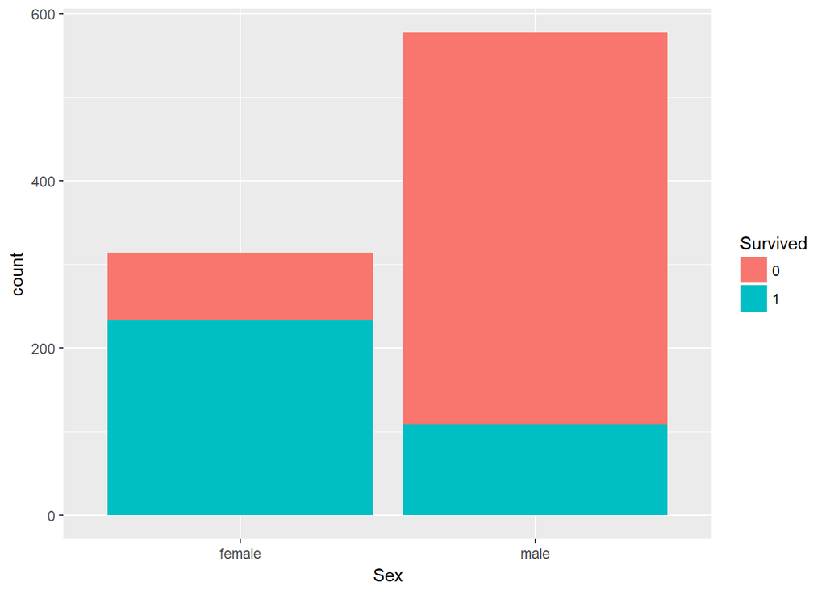

```r
ggplot(data=train, aes(Sex, fill=Survived)) + geom_bar(stat="count", position="stack")
```

```r
model2<-naiveBayes(Survived~Sex+Pclass, data=train)

model2$apriori
```

```
## Y
##   0   1
## 549 342
```

```r
model2$tables
```

```
## $Sex
##    Sex
## Y      female      male
##   0 0.1475410 0.8524590
##   1 0.6812865 0.3187135
##
## $Pclass
##    Pclass
## Y           1         2         3
##   0 0.1457195 0.1766849 0.6775956
##   1 0.3976608 0.2543860 0.3479532
```

```r
#Zalozmy, ze intersuje nas p-stwo ratunku  dla kobiety w pierwszej klasie


P<-(model2$tables$Pclass[2,1]*model2$tables$Sex[2,"female"]*model2$apriori[2] ) /
(model2$tables$Pclass[2,1]*model2$tables$Sex[2,"female"]*model2$apriori[2] + model2$tables$Pclass[1,1]*model2$tables$Sex[1,"female"]*model2$apriori[1])
P
```

```
##         1
## 0.8870048
```

```r
#Predykcja na pozostałych obserwacjach:

pred2<-predict(model2, train, type="raw")
head(cbind(train[,c("Pclass","Sex","Survived")],pred2))
```

```
##   Pclass    Sex Survived         0         1
## 1      3   male        0 0.8931762 0.1068238
## 2      1 female        1 0.1129952 0.8870048
## 3      3 female        1 0.4036916 0.5963084
## 4      1 female        1 0.1129952 0.8870048
## 5      3   male        0 0.8931762 0.1068238
## 6      3   male        0 0.8931762 0.1068238
```

## Ciagłe predyktory

Prawdopodobieństwo aposteriori przynależnośći do klasy:

$p_k(X) = Pr(Y=k|X=x) = \frac{\pi_k f_k(x)}{\sum_{r=1}^{K}\pi_r f_r(x)}$

$\pi_k$ - szacujemy na podstawie próby danych (częstość wystąpień obserwacji w próbie)

$f_k(X) = Pr(X=x|Y=k)$ gęstość rozkładu zmiennej X dla obserwacji należących do K-tej klasy.

Równoważnie można wybrać tę klasę, dla której największa jest wartość: $\pi_k f_k(x)$

```r
data("iris")

summary(iris)
```

```
##   Sepal.Length    Sepal.Width     Petal.Length    Petal.Width
##  Min.   :4.300   Min.   :2.000   Min.   :1.000   Min.   :0.100
##  1st Qu.:5.100   1st Qu.:2.800   1st Qu.:1.600   1st Qu.:0.300
##  Median :5.800   Median :3.000   Median :4.350   Median :1.300
##  Mean   :5.843   Mean   :3.057   Mean   :3.758   Mean   :1.199
##  3rd Qu.:6.400   3rd Qu.:3.300   3rd Qu.:5.100   3rd Qu.:1.800
##  Max.   :7.900   Max.   :4.400   Max.   :6.900   Max.   :2.500
##        Species
##  setosa    :50
##  versicolor:50
##  virginica :50
##
##
##
```

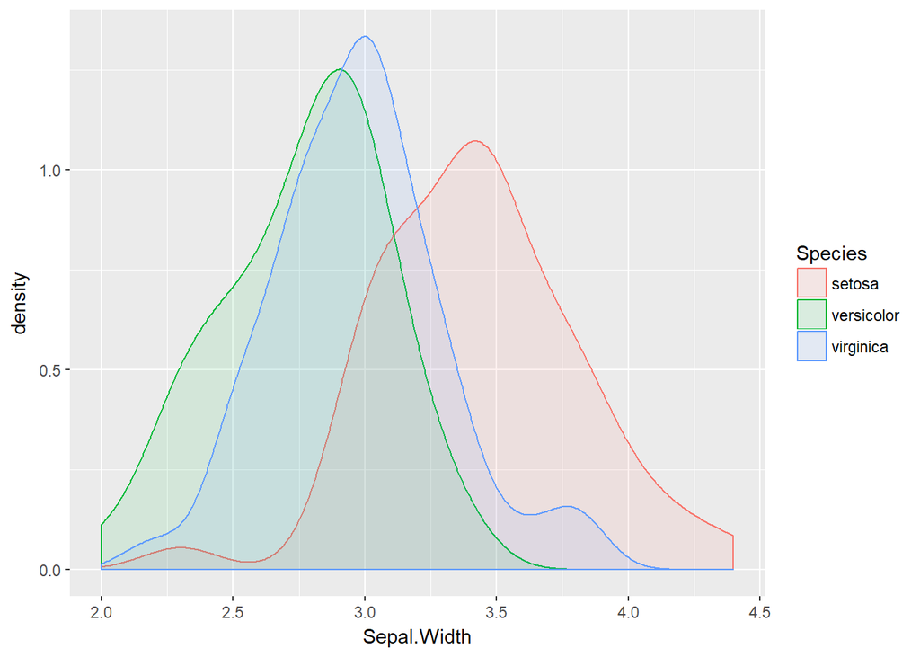

```r
ggplot(data=iris, aes(x=Sepal.Width, color=Species, fill=Species)) + geom_density(alpha=0.1) + scale_fill_discrete()
```

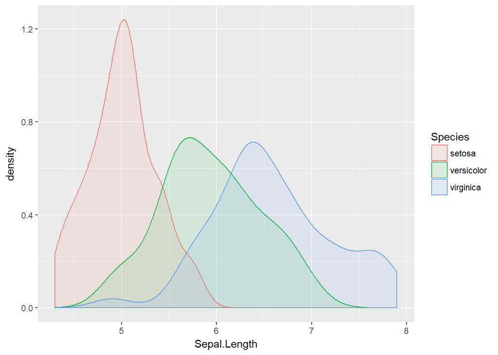

```r
ggplot(data=iris, aes(x=Sepal.Length, color=Species, fill=Species)) + geom_density(alpha=0.1) + scale_fill_discrete()
```

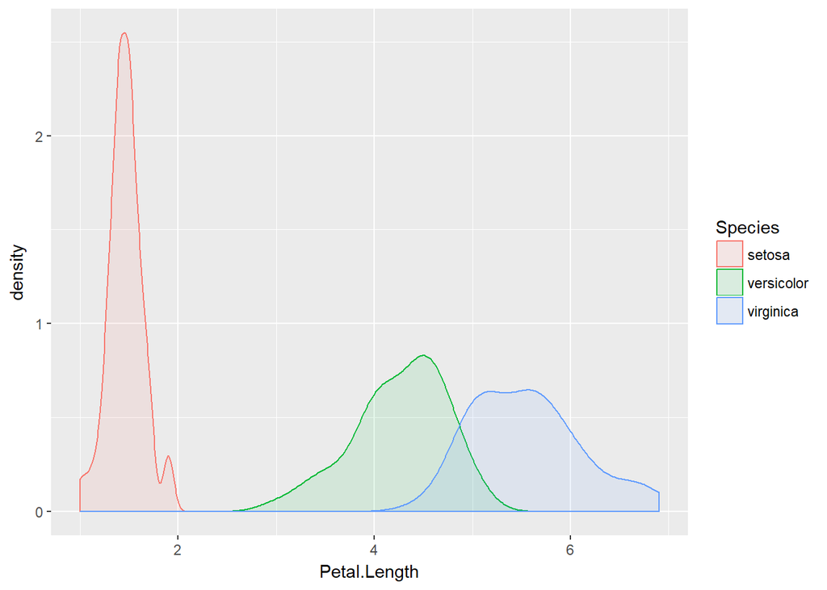

```r
ggplot(data=iris, aes(x=Petal.Length, color=Species, fill=Species)) + geom_density(alpha=0.1) + scale_fill_discrete()
```

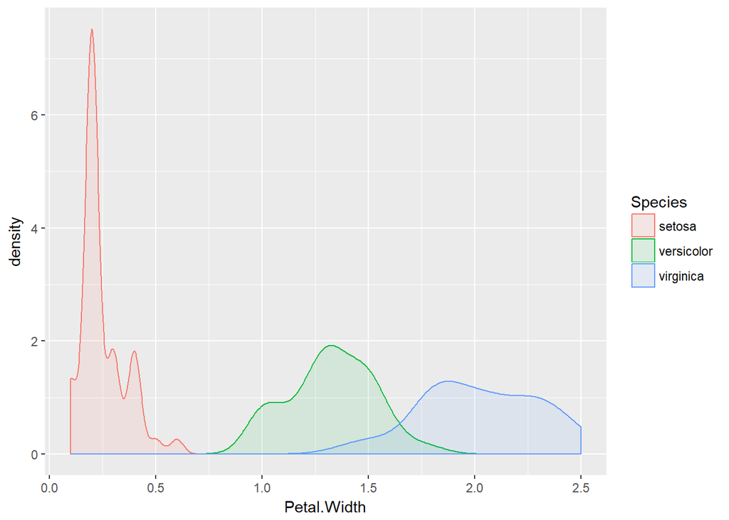

```r
ggplot(data=iris, aes(x=Petal.Width, color=Species, fill=Species)) + geom_density(alpha=0.1) + scale_fill_discrete()
```

### Jedna zmienna objaśniająca

Załóżmy, że

$f_k(x)$ ma rozkład normalny z parametrami $\mu_k$ oraz $\sigma_k^2$

```r
model<-naiveBayes(Species~Sepal.Width, data=iris)
model$apriori
```

```
## Y
##     setosa versicolor  virginica
##         50         50         50
```

```r
model$tables
```

```
## $Sepal.Width
##             Sepal.Width
## Y             [,1]      [,2]
##   setosa     3.428 0.3790644
##   versicolor 2.770 0.3137983
##   virginica  2.974 0.3224966
```

```r
#Wartość funkcji rozkładu gęstości pstwa dla rozkładu normalnego
# Dla wartości Sepal.Width = 3.5 mamy odpowiednie wartości rozkładów
P_Species<- dnorm(c(3.5,3.5,3.5), mean=model$tables$Sepal.Width[,1], sd=model$tables$Sepal.Width[,2])/
                sum(dnorm(c(3.5,3.5,3.5), mean=model$tables$Sepal.Width[,1], sd=model$tables$Sepal.Width[,2]))

P_Species
```

```
## [1] 0.71496909 0.05875149 0.22627942
```

```r
pred<-predict(model, iris, type="raw")
head( cbind (iris$Sepal.Width, pred ))
```

```
##             setosa  versicolor  virginica
## [1,] 3.5 0.7149691 0.058751495 0.22627942
## [2,] 3.0 0.2014921 0.351961933 0.44654596
## [3,] 3.2 0.3748284 0.212181702 0.41298992
## [4,] 3.1 0.2782470 0.281142856 0.44061017
## [5,] 3.6 0.8074072 0.032710174 0.15988265
## [6,] 3.9 0.9566028 0.003833692 0.03956354
```

### Wiele zmiennych objaśniajacych

```r
model<-naiveBayes(Species~., data=iris)
model$apriori
```

```
## Y
##     setosa versicolor  virginica
##         50         50         50
```

```r
model$tables
```

```
## $Sepal.Length
##             Sepal.Length
## Y             [,1]      [,2]
##   setosa     5.006 0.3524897
##   versicolor 5.936 0.5161711
##   virginica  6.588 0.6358796
##
## $Sepal.Width
##             Sepal.Width
## Y             [,1]      [,2]
##   setosa     3.428 0.3790644
##   versicolor 2.770 0.3137983
##   virginica  2.974 0.3224966
##
## $Petal.Length
##             Petal.Length
## Y             [,1]      [,2]
##   setosa     1.462 0.1736640
##   versicolor 4.260 0.4699110
##   virginica  5.552 0.5518947
##
## $Petal.Width
##             Petal.Width
## Y             [,1]      [,2]
##   setosa     0.246 0.1053856
##   versicolor 1.326 0.1977527
##   virginica  2.026 0.2746501
```

```r
pred_Species<-predict(model, iris)
head(cbind(iris, pred_Species ))
```

```
##   Sepal.Length Sepal.Width Petal.Length Petal.Width Species pred_Species
## 1          5.1         3.5          1.4         0.2  setosa       setosa
## 2          4.9         3.0          1.4         0.2  setosa       setosa
## 3          4.7         3.2          1.3         0.2  setosa       setosa
## 4          4.6         3.1          1.5         0.2  setosa       setosa
## 5          5.0         3.6          1.4         0.2  setosa       setosa
## 6          5.4         3.9          1.7         0.4  setosa       setosa
```

```r
table(iris$Species, pred_Species)
```

```
##             pred_Species
##              setosa versicolor virginica
##   setosa         50          0         0
##   versicolor      0         47         3
##   virginica       0          3        47
```

```r
pred<-predict(model, iris, type="raw")
head(cbind(iris, pred ))
```

```
##   Sepal.Length Sepal.Width Petal.Length Petal.Width Species setosa
## 1          5.1         3.5          1.4         0.2  setosa      1
## 2          4.9         3.0          1.4         0.2  setosa      1
## 3          4.7         3.2          1.3         0.2  setosa      1
## 4          4.6         3.1          1.5         0.2  setosa      1
## 5          5.0         3.6          1.4         0.2  setosa      1
## 6          5.4         3.9          1.7         0.4  setosa      1
##     versicolor    virginica
## 1 2.981309e-18 2.152373e-25
## 2 3.169312e-17 6.938030e-25
## 3 2.367113e-18 7.240956e-26
## 4 3.069606e-17 8.690636e-25
## 5 1.017337e-18 8.885794e-26
## 6 2.717732e-14 4.344285e-21
```

# Sieci Bayesa

## Definicja

Sieć bayesowska to acykliczny (nie zawierający cykli) graf skierowany, w którym:

• węzły reprezentują zmienne losowe (np. temperaturę jakiegoś źródła, stan pacjenta, cechę obiektu itp.)

• łuki (skierowane) reprezentują zależnośd typu „ zmienna X ma bezpośredni wpływ na zmienna Y”,

• każdy węzeł X ma stowarzyszona z nim tablice prawdopodobieństw warunkowych określających wpływ wywierany na X przez jego poprzedników (rodziców) w grafie,

• zmienne reprezentowane przez węzły przyjmują wartości dyskretne (np.: TAK, NIE).

## Przykład

### ASIA network from Lauritzen & Spiegelhalter (1988)

“Shortness-of-breath (dyspnoea) may be due to tuberculosis, lung cancer or bronchitis, or none of them, or more than one of them.

A recent visit to Asia increases the chances of tuberculosis, while smoking is known to be a risk factor for both lung cancer and bronchitis.

The results of a single chest X-ray do not discriminate between lung cancer and tuberculosis, as neither does the presence or absence of dyspnoea.”

• T (tuberculosis), a two-level factor with levels yes and no.

• L (lung cancer), a two-level factor with levels yes and no.

• B (bronchitis), a two-level factor with levels yes and no.

• A (visit to Asia), a two-level factor with levels yes and no.

• S (smoking), a two-level factor with levels yes and no.

• X (chest X-ray), a two-level factor with levels yes and no.

• E (tuberculosis versus lung cancer/bronchitis), a two-level factor with levels yes and no.

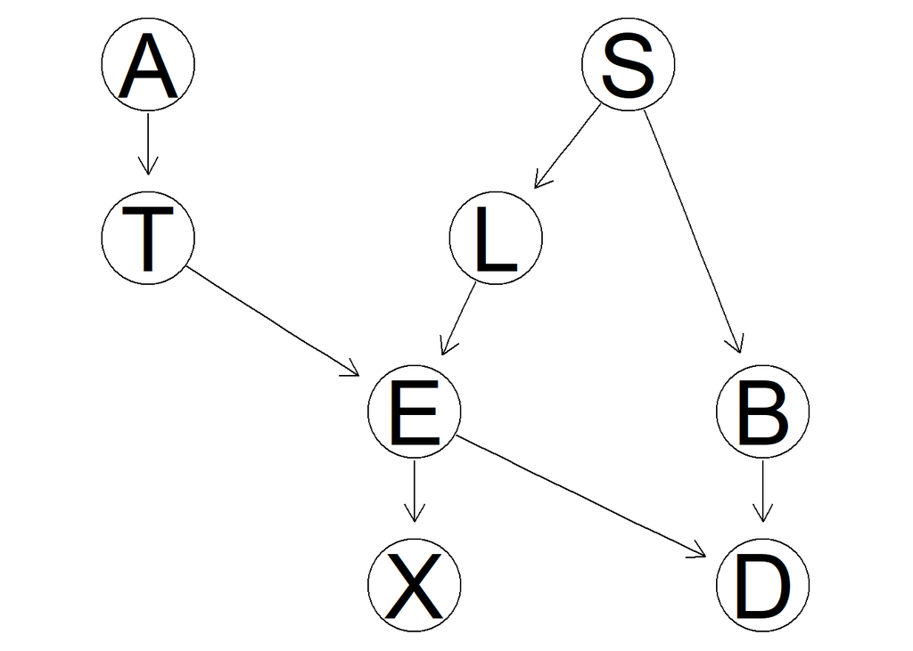

```r
library(bnlearn)
library(DiagrammeR)
library(Rgraphviz)
# create and plot the network structure.
asia.dag = model2network("[A][S][T|A][L|S][B|S][D|B:E][E|T:L][X|E]")
p<-graphviz.plot(asia.dag)
```

### Conditional probability tables (CPT)

Tablica prawdopodobieństw warunkowych

```r
lv = c("yes", "no")

A.prob = array(c(0.01, 0.99), dim = 2, dimnames = list(A = lv))
S.prob = array(c(0.01, 0.99), dim = 2, dimnames = list(A = lv))

T.prob = array(c(0.05, 0.95, 0.01, 0.99), dim = c(2, 2),dimnames = list(T = lv, A = lv))

L.prob = array(c(0.1, 0.9, 0.01, 0.99), dim = c(2, 2),dimnames = list(L = lv, S = lv))
B.prob = array(c(0.6, 0.4, 0.3, 0.7), dim = c(2, 2),dimnames = list(B = lv, S = lv))
D.prob = array(c(0.9, 0.1, 0.7, 0.3, 0.8, 0.2, 0.1, 0.9), dim = c(2, 2, 2), dimnames = list(D = lv, B = lv, E = lv))

E.prob = array(c(1, 0, 1, 0, 1, 0, 0, 1), dim = c(2, 2, 2),dimnames = list(E = lv, T = lv, L = lv))
X.prob = array(c(0.98, 0.02, 0.05, 0.95), dim = c(2, 2),dimnames = list(X = lv, E = lv))

cpt = list(A = A.prob, S = S.prob, T = T.prob, L = L.prob, B = B.prob,D = D.prob, E = E.prob, X = X.prob)
bn = custom.fit(asia.dag, cpt)

bn$D
```

```
##
##   Parameters of node D (multinomial distribution)
##
## Conditional probability table:
##
## , , E = yes
##
##      B
## D     yes  no
##   yes 0.9 0.7
##   no  0.1 0.3
##
## , , E = no
##
##      B
## D     yes  no
##   yes 0.8 0.1
##   no  0.2 0.9
```

### Conditional probability queries (CPQs)

Wnioskowanie o zdarzeniach w sieciach Bayesa.

Jakie jest p-stwo zajścia zdarzenia B = yes pod warunkiem zobserwowania A= no

```r
cpquery(bn, event=(B == "yes"), evidence=(A == "no"))
```

```
## [1] 0.2858296
```

### Przykład dla sieci

Dane można pobrać z: http://www.bnlearn.com/bnrepository/

Przykład do uruchomienia po przekopiowaniu pliku earthquake.rda do folderu roboczego.

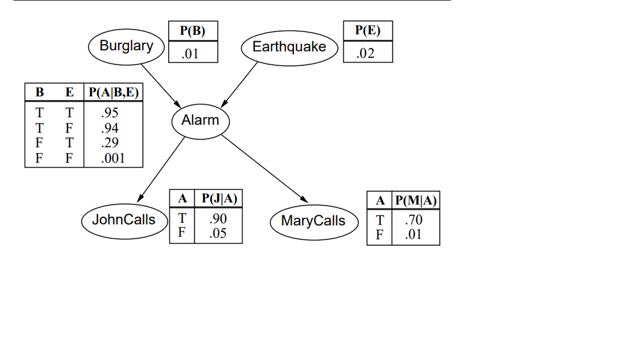

Siec

Alarm może zostać uruchomiony w wyniku trzęsienia ziemii lub włamania. Moi sąsiedzi, John lub Mary zazwyczaj powiadamiają mnie, gdy mają podejrzenie, że coś nie tak jest z moim domem.

```r
load(file="earthquake.rda")

bn$Burglary$prob
```

```
##  True False
##  0.01  0.99
```

```r
bn$Earthquake
```

```
##
##   Parameters of node Earthquake (multinomial distribution)
##
## Conditional probability table:
##   True False
##  0.02  0.98
```

```r
bn$Alarm
```

```
##
##   Parameters of node Alarm (multinomial distribution)
##
## Conditional probability table:
##
## , , Earthquake = True
##
##        Burglary
## Alarm    True False
##   True  0.950 0.290
##   False 0.050 0.710
##
## , , Earthquake = False
##
##        Burglary
## Alarm    True False
##   True  0.940 0.001
##   False 0.060 0.999
```

```r
bn$JohnCalls
```

```
##
##   Parameters of node JohnCalls (multinomial distribution)
##
## Conditional probability table:
##
##          Alarm
## JohnCalls True False
##     True  0.90  0.05
##     False 0.10  0.95
```

```r
cpquery(bn, JohnCalls=="True", TRUE)
```

```
## [1] 0.064
```

```r
cpquery(bn, JohnCalls=="False", TRUE)
```

```
## [1] 0.9336
```

```r
#ustawienie liczby próbek dla Logical Sampling
cpquery(bn, JohnCalls=="False", Alarm=="True", n=900000)
```

```
## [1] 0.09660319
```

```r
cpquery(bn, Alarm=="True", MaryCalls=="True", n=900000)
```

```
## [1] 0.5364393
```

```r
x<-cpquery(bn, Alarm=="True", TRUE, n=9000000)
p1<-0.7*x / (0.7*x + 0.01*(1-x))


cpquery(bn, JohnCalls=="True", MaryCalls=="True", n=900000)
```

```
## [1] 0.507672
```

```r
p1*0.9 + (1-p1)*0.05
```

```
## [1] 0.5038898
```

```r
#Prawdopodobienstwo wyzwolenia alarmu

bn$Alarm$prob["True",,]
```

```
##         Earthquake
## Burglary  True False
##    True  0.950 0.940
##    False 0.290 0.001
```

```r
t(bn$Burglary$prob)
```

```
##      True False
## [1,] 0.01  0.99
```

```r
bn$Alarm$prob["True",,]%*%(bn$Earthquake$prob)
```

```
##
## Burglary    [,1]
##    True  0.94020
##    False 0.00678
```

```r
cpquery(bn, Burglary=="True", TRUE, n=9000000)
```

```
## [1] 0.009989667
```

```r
cpquery(bn, Earthquake=="True", TRUE, n=9000000)
```

```
## [1] 0.02002778
```

```r
cpquery(bn, Alarm=="True", (Burglary=="True"  & Earthquake=="True"), n=9000000)* cpquery(bn, Burglary=="True", TRUE, n=9000000)*cpquery(bn, Earthquake=="True", TRUE, n=9000000)
```

```
## [1] 0.0001926554
```

```r
0.95*0.01*0.02
```

```
## [1] 0.00019
```

```r
cpquery(bn, Alarm=="True", (Burglary=="False"  & Earthquake=="False"), n=9000000)* cpquery(bn, Burglary=="False", TRUE, n=9000000)*cpquery(bn, Earthquake=="False", TRUE, n=9000000)
```

```
## [1] 0.000989215
```

```r
0.01*0.99*0.98
```

```
## [1] 0.009702
```

```r
cpquery(bn, Alarm=="True", (Burglary=="True"  & Earthquake=="False"), n=9000000)* cpquery(bn, Burglary=="True", TRUE, n=9000000)*cpquery(bn, Earthquake=="False", TRUE, n=9000000)
```

```
## [1] 0.009198361
```

```r
0.94*0.01*0.98
```

```
## [1] 0.009212
```

```r
cpquery(bn, Alarm=="True", (Burglary=="False"  & Earthquake=="True"), n=9000000)* cpquery(bn, Burglary=="False", TRUE, n=9000000)*cpquery(bn, Earthquake=="True", TRUE, n=9000000)
```

```
## [1] 0.005742802
```

```r
0.29*0.99*0.02
```

```
## [1] 0.005742
```

```r
cpquery(bn, Alarm=="True", (Burglary=="False"), n=9000000)
```

```
## [1] 0.006754434
```

```r
0.29*0.02 + 0.01*0.98
```

```
## [1] 0.0156
```

```r
cpquery(bn, Alarm=="True", (Earthquake=="False"), n=9000000)
```

```
## [1] 0.01037438
```

```r
0.94*0.01 + 0.001*0.99
```

```
## [1] 0.01039
```

```r
cpquery(bn, Alarm=="True", TRUE, n=9000000)
```

```
## [1] 0.01609244
```

```r
0.95*0.01*0.02 + 0.94*0.01*0.98 + 0.29*0.99*0.02+0.001*0.99*0.98
```

```
## [1] 0.0161142
```

### Uczenie sieci Bayesa z danych